# *Kaggle Cars Dataset Exploration*

## *11. Year Vs. Time-To-60*

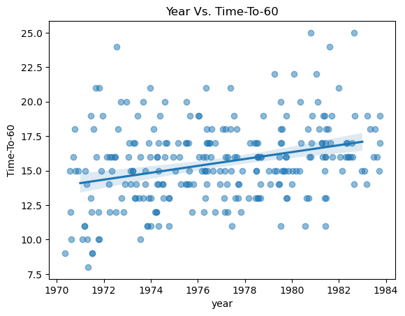

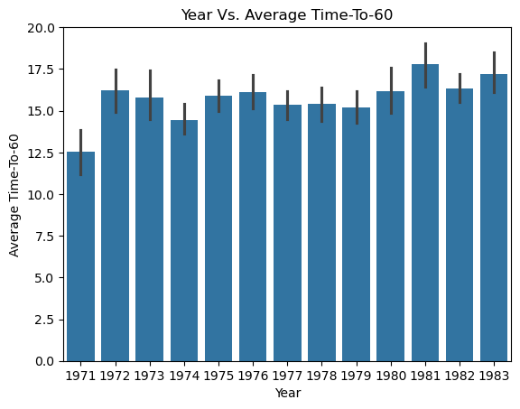

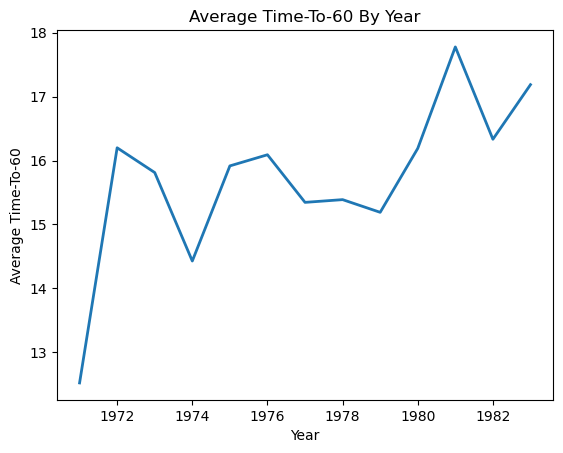

*Recently made cars in the data don't seem to have improvements in the accelaration as much as the older models, they take longer time to reach 60 miles per hour.*

## *12. Year Vs. Horsepower*

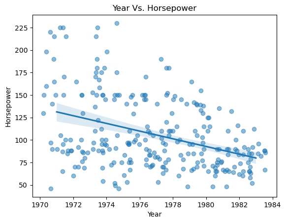

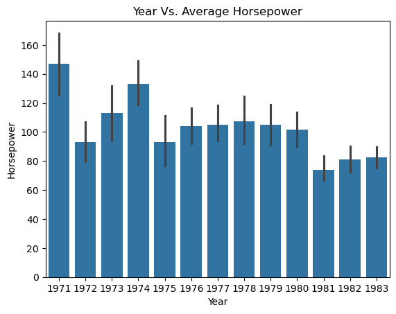

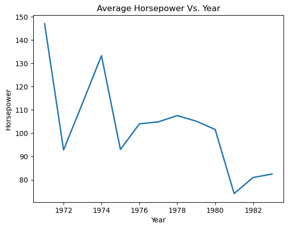

*The engine horsepower of recently made cars in the data is dropping overtime. Speed appears to be regarded as less important in a car.*

## *Conclusion of The Bivariate Exploration:*

*First, the **cubicinches** and **weightlbs** are positively correlated. The larger the car model, the heavier it becomes. The **weightlbs** and **mpg** are negatively correlated. The heavier the car model, the fewer miles it travels per gallon, thus it consumes more fuel. The **hp** and **time-to-60** are negatively correlated, meaning that the higher the horsepower of a car, the less time it takes to reach 60 miles per hour. The **hp** and **mpg** are negatively correlated, meaning that the higher the horsepower of a car engine, the fewer miles it travels per gallon. On average the **Japanese** brands have the highest fuel efficiency than the **European** and **US** brands that have lower mpg. On average, the **US** brands tend to have a larger size than the **European** and **Japanese** brands. On average the **US** brands tend to have less time to reach their speed of 60 miles per hour than the **European** and **Japanese** brands. Lastly looking at how variables change overtime, the **mpg** and **year** features are positively correlated, meaning that recently designed models have higher mpg and thus burn less fuel. The correlation is also positive between **time-to-60** and **year**, meaning with time, cars have less accelaration, which takes more time to reach the speed of 60 miles per hour. The correlation is negative between **year** and the following variables: **cylinders**, **weightlbs** (and **cubicinches** for that matter, since these two variables are positively correlated.), **hp**, which means recent cars have engines with less number of cylinders, these cars are relatively lighter and hence smaller, and lastly, their engines is less stronger with lower horsepower.*

## *Multivariate Exploration*

*In this section, we'll create plots of three or more variables to investigate our data even further.*

## *1. Cubicinches Vs. Weights By Brand*

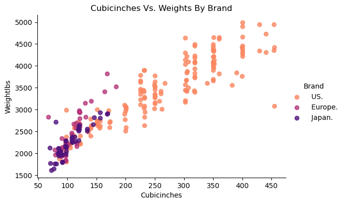

*The result is the same as the previous conclusions. The **US** brands are the largest and heaviest than the **European** and **Japanese** brands. The **US** models outnumber the **Japanese** and the **European** models in frequency.*

## *2. Weights Vs. Miles Per Gallon By Brand*

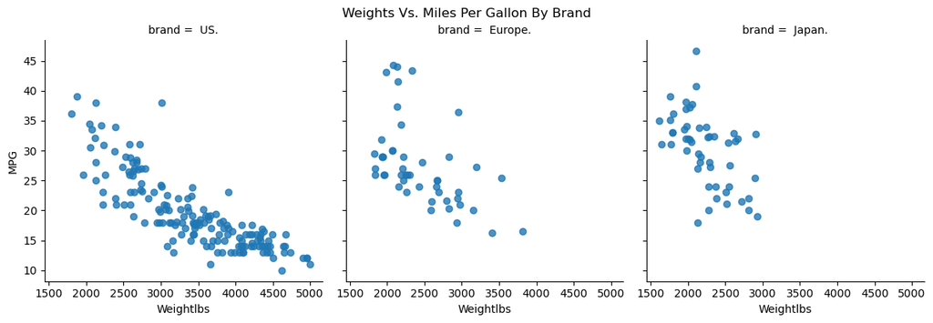

*This facet grid reconfirms what we concluded from the bivariate visualizations. On average, the **US** brands have the highest weights and the lowest mpg (fuel efficiency). The **Japanese** and the **European** brands have higher MPG and lower weights. Also, the **US** models are much more frequent in the dataset than the other two brands, and the correlation is negative between the car's fuel efficiency and its weight in pounds.*

## *3. Horsepower Vs. Time-To-60 By Brand*

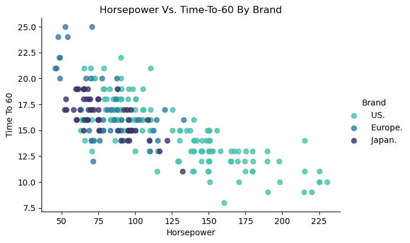

*The result is still the same as the previous conclusions. The **US** brands have higher horsepower and therefore less time to 60 than the **European** and **Japanese** brands. That is why the US brands are faster and thus burn more fuel. The **US** brands are much more frequent than others, and also the correlation between these two variables is negative.*

## *4. Horsepower Vs. Miles Per Gallon By Brand*

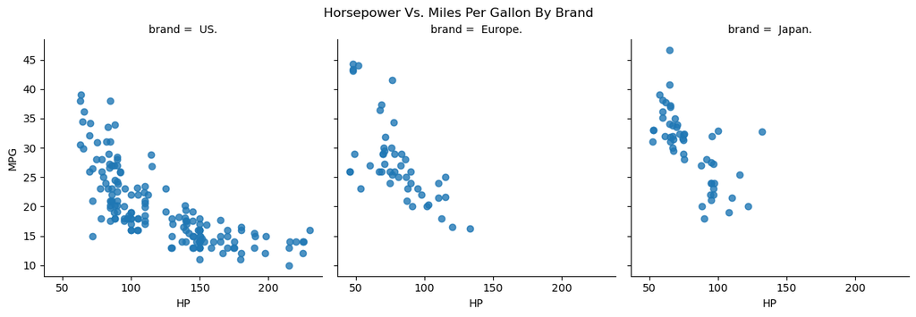

*The facet grid reconfirms what we concluded from the previous bivariate visualizations. On average, the **US** brands have higher horsepower but lower mpg (fuel efficiency). The **Japanese** and the **European** brands have higher mpg but lower horsepower. Again, the **US** brands are much more frequent in the data than the **Japanese** and the **European** brands, and the correlation is negative between these two variables.*

## *5. Year Vs. Miles Per Gallon By Brand*

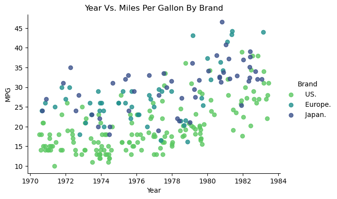

*The scatterplot shows a gradual increase in fuel efficiency of the new models over time for the three different brands, which indicates the importance of the fuel efficiency aspect of a car. Also, the **US** brands have lower mpg than the **Japanese** and **European** brands and are much more frequent, and the correlation between fuel consumption and year is positive.*

## *Conclusion of The Multivariate Exploration:*

*In this section, I wanted to understand more about the **brand** feature, so I used non-positional encodings and faceting to visualize this feature. I plotted every scatterplot again with color encodings for the brand feature. The multivariate plots reconfirmed the insights we learned from the univariate and bivariate visualizations. The **cubicinches** and **weightlbs** are positively correlated. The **US** brands are the largest and heaviest than the **European** and **Japanese** brands. The **weightlbs** and **mpg** are negatively correlated. On average, the **US** brands have the highest weights and the lowest MPG (fuel efficiency), but the **Japanese** and the **European** brands have higher MPG and lower weights. The **hp** and **time-to-60** are negatively correlated. The **US** brands have higher horsepower and therefore less time-to-60 (more acceleration) than the **European** and **Japanese** brands. The **year** and **mpg** are positively correlated. With time, the car models in the data were improved regarding fuel consumption and have higher MPG. Maybe due to environmental awareness or competition between brands in reducing fuel costs and carbon dioxide emissions.*